# 07_unit_hyp_pyth_thm

## 07_unit_hyp_pyth_thm

#### Question

1. A right triangle is drawn with a hypotenuse of length 1 and a leg of length $\frac{7\sqrt{14}}{31}$. The other leg is of length $x$.

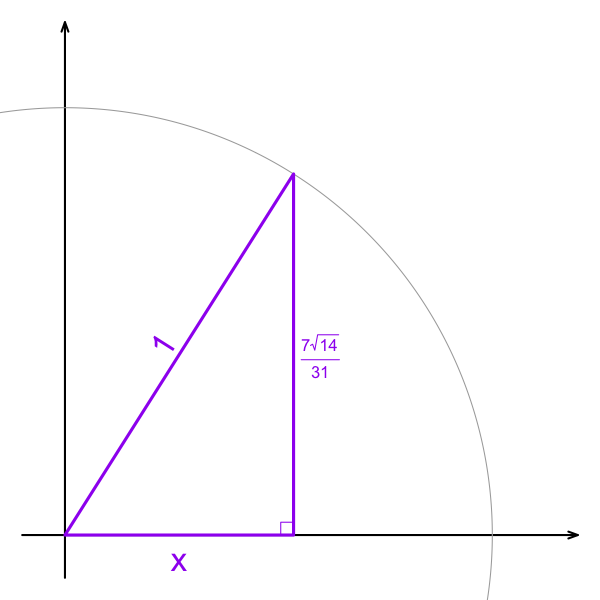

   The other leg can be expressed as a fraction of a radical.

   $$x~=~\frac{a\sqrt{b}}{c}$$

   where $a$, $b$, and $c$ are positive integers. Find the length of the other leg. Express the length exactly by stating the values of $a$, $b$, and $c$.
   - $a=$
   - $b=$
   - $c=$

#### Question

2. A right triangle is drawn with a hypotenuse of length 1 and a leg of length $\frac{5\sqrt{5}}{13}$. The other leg is of length $x$.

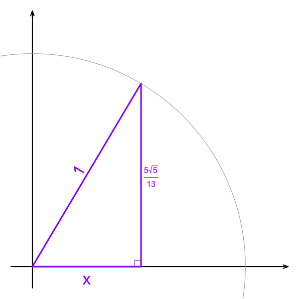

   The other leg can be expressed as a fraction of a radical.

   $$x~=~\frac{a\sqrt{b}}{c}$$

   where $a$, $b$, and $c$ are positive integers. Find the length of the other leg. Express the length exactly by stating the values of $a$, $b$, and $c$.
   - $a=$
   - $b=$
   - $c=$

#### Question

3. A right triangle is drawn with a hypotenuse of length 1 and a leg of length $\frac{3\sqrt{26}}{28}$. The other leg is of length $x$.

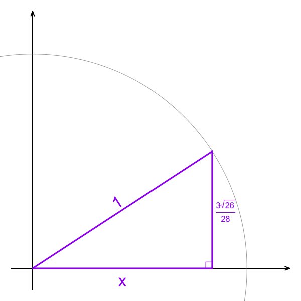

   The other leg can be expressed as a fraction of a radical.

   $$x~=~\frac{a\sqrt{b}}{c}$$

   where $a$, $b$, and $c$ are positive integers. Find the length of the other leg. Express the length exactly by stating the values of $a$, $b$, and $c$.
   - $a=$
   - $b=$
   - $c=$

#### Question

4. A right triangle is drawn with a hypotenuse of length 1 and a leg of length $\frac{7\sqrt{17}}{31}$. The other leg is of length $x$.

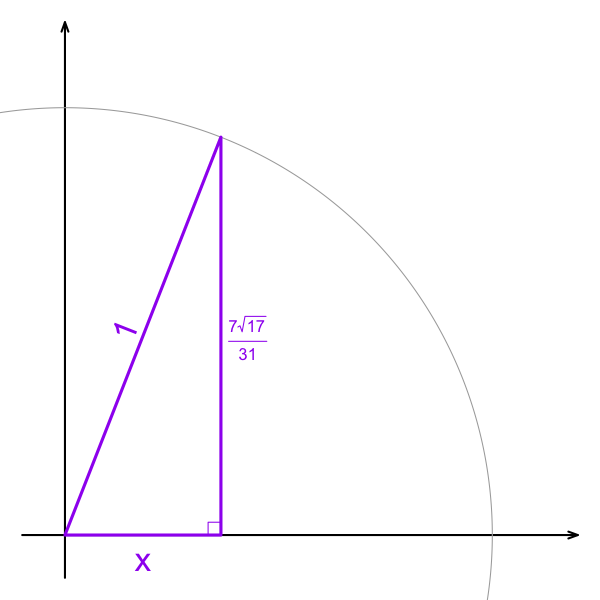

   The other leg can be expressed as a fraction of a radical.

   $$x~=~\frac{a\sqrt{b}}{c}$$

   where $a$, $b$, and $c$ are positive integers. Find the length of the other leg. Express the length exactly by stating the values of $a$, $b$, and $c$.
   - $a=$
   - $b=$
   - $c=$

#### Question

5. A right triangle is drawn with a hypotenuse of length 1 and a leg of length $\frac{4\sqrt{19}}{27}$. The other leg is of length $x$.

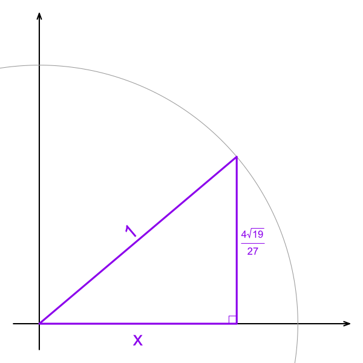

   The other leg can be expressed as a fraction of a radical.

   $$x~=~\frac{a\sqrt{b}}{c}$$

   where $a$, $b$, and $c$ are positive integers. Find the length of the other leg. Express the length exactly by stating the values of $a$, $b$, and $c$.
   - $a=$
   - $b=$
   - $c=$

#### Question

6. A right triangle is drawn with a hypotenuse of length 1 and a leg of length $\frac{2\sqrt{34}}{17}$. The other leg is of length $x$.

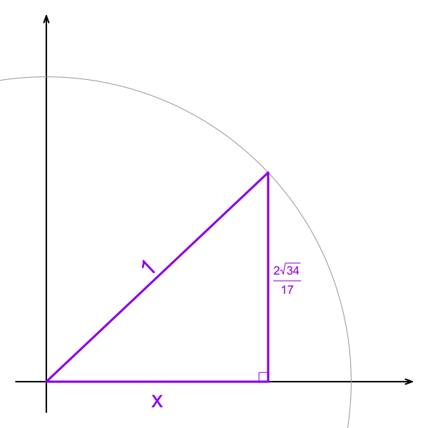

   The other leg can be expressed as a fraction of a radical.

   $$x~=~\frac{a\sqrt{b}}{c}$$

   where $a$, $b$, and $c$ are positive integers. Find the length of the other leg. Express the length exactly by stating the values of $a$, $b$, and $c$.
   - $a=$
   - $b=$
   - $c=$

#### Question

7. A right triangle is drawn with a hypotenuse of length 1 and a leg of length $\frac{5\sqrt{13}}{26}$. The other leg is of length $x$.

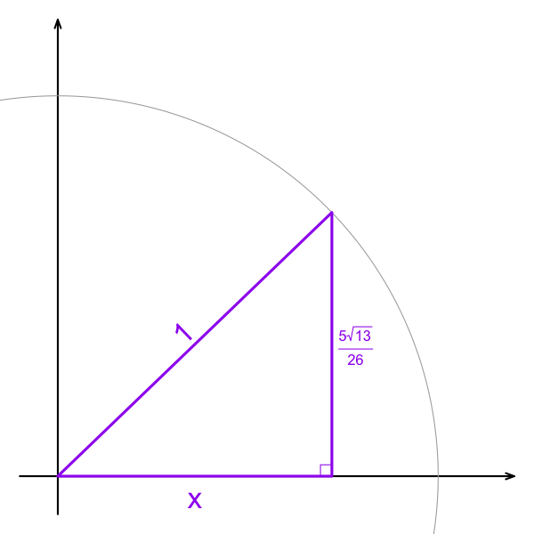

   The other leg can be expressed as a fraction of a radical.

   $$x~=~\frac{a\sqrt{b}}{c}$$

   where $a$, $b$, and $c$ are positive integers. Find the length of the other leg. Express the length exactly by stating the values of $a$, $b$, and $c$.
   - $a=$
   - $b=$
   - $c=$

#### Question

8. A right triangle is drawn with a hypotenuse of length 1 and a leg of length $\frac{2\sqrt{34}}{17}$. The other leg is of length $x$.

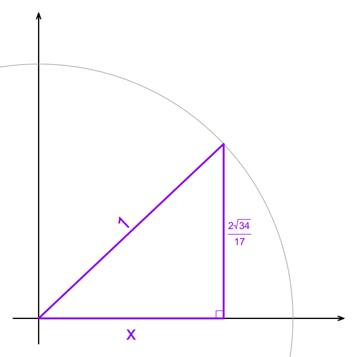

   The other leg can be expressed as a fraction of a radical.

   $$x~=~\frac{a\sqrt{b}}{c}$$

   where $a$, $b$, and $c$ are positive integers. Find the length of the other leg. Express the length exactly by stating the values of $a$, $b$, and $c$.
   - $a=$
   - $b=$
   - $c=$